# Lab Exercises 5 Solutions

## Question 1

#### (a) The variance is known.

Suppose that we have a sample of size n, independently generated from a $N(\mu,\sigma^2)$ distribution. The likelihood term now is
$$p(y \mid \mu,\sigma^{2})\propto exp\left(-\frac{1}{2\sigma^2}n(\mu - \bar{y})^2\right)$$

##### (i) Using the **conjugate prior** on the mean is also a Normal: $\mu \sim N(\mu_{0},\sigma_{0}^{2})$

$$\mu \mid \sigma^{2},y
\sim N\left(\frac{n\bar{y}/\sigma^{2} + \mu_{0}/\sigma_{0}^{2}}{n/\sigma^{2}+1/\sigma_{0}^{2}},\> \frac{1}{n/\sigma^{2}+1/\sigma_{0}^{2}} \right)$$

##### (ii) Using the **noninformative prior** let $\sigma^2 \rightarrow \infty$, we see that

$$p(\mu \mid \sigma^2, y) \rightarrow (\sigma^2/n)^{-1/2}exp\left[-\frac{n}{2\sigma^2}(\mu -\bar{y})^2\right],$$

i.e.,

$$\mu \mid \sigma^{2},y \sim N (\bar{y},\sigma^{2}/n)$$
.

#### (b) **The mean is known**. The likelihood here is:

$$p(y \mid \mu, \sigma^2) \propto (\sigma^2)^{-n/2}exp\left(-\sum\limits_{i=1}^{n}\frac{(y_i-\mu)^2}{2\sigma^2}\right).$$
**[it is not the same as the likelihood of part(a) as the variance is now a parameter]**

##### (i) **Conjugate prior**

The conjugate prior for the inverse gamma distribution is $p(\sigma^2) \propto (\sigma^2)^{-(\alpha +1)}exp\left(-\frac{\beta}{\sigma^2}\right)$, and so in general the posterior is
$$\begin{aligned}
p(\sigma^{2}\mid \mu, y) &\propto p(y\mid \mu,\sigma^{2})p(\sigma^2\mid \mu) \\
&\propto (\sigma^2)^{(\frac{n}{2}+\alpha+1)}\,exp\left(-\frac{1}{\sigma^{2}}\left(\frac{\sum(y_i-\mu)^2}{2} + \beta \right)\right)
\end{aligned}$$
which is equivalent to $\sigma^{2} \mid \mu,y \sim I.G.\left(A=\frac{n}{2} + \alpha,\> B=\frac{\sum(y_i-\mu)^2}{2} + \beta\right)$.

$$\sigma^2 \mid \mu,y \sim I.G.\left(A=\frac{n}{2},\> B=\frac{\sum(y_i-\mu)^2}{2}\right)$$

#### (c) **Both unknown**

For this case, our aims are to find:

joint posterior $\mu,\sigma^{2} \mid y$  
marginal posterior distributions $\mu \mid y$ or $\sigma^{2} \mid y$

conditional posterior distributions $\mu \mid y,\sigma^{2}$ or $\sigma^{2} \mid \mu, y$

##### (i) Noninformative prior $p(\mu,\sigma^2) \propto 1/\sigma^{2}$.

The marginal posterior are:
$$\mu \mid y \sim t_{n-1}(\bar{y}, s^2/n).\\
\sigma^2 \mid y \sim I.G.\left( \alpha = \frac{n-1}{2},\> \beta = \frac{(n-1)s^2}{2}\right)$$
The conditional posteriors are
$$\mu \mid y,\sigma^2 \sim N(\bar{y}, \sigma^2/n).\\
\sigma^2 \mid y, \mu \sim I.G.\left(\frac{n}{2},\> \frac{\sum(y_t-\mu)^2}{2}\right)$$
Using the above results and MC methods, we are able to find the joint posterior $\mu ,\sigma^{2} \mid y$ numerically.

##### (ii) For a family of conjugate priors, please see BDA Section 3.3.

## Question 2

Simulate from the Monte Carlo scheme 1. $p(\mu\mid y)$ 2. $p(\sigma^2 \mid y,\mu)$ for the treatment sample in the chicken flow example (in the file stat3120data.xls). Save the results for use in Q3.

#### (a) Obtain both the histogram estimate and the mixture estimate of $\mu_{T}$.

#### (b) Obtain both the histogram estimate and the mixture estimate of $\sigma_{T}^{2}$.

1. and (b) We know that

$$1.\quad \frac{\mu-\bar{y}}{s/\sqrt{n}} \sim t_{n_1} \\
2.\quad \sigma^2 \mid \mu, y \sim I.G.\left(A=\frac{n}{2},\> B = \frac{\sum(y_i-\mu)^2}{2}\right)$$
Simulating from this for the treatment sample $y_{t}$ gives:

```r
yt <- na.omit(data$treatment)
nt <- length(yt)
mut <- mean(yt)+sd(yt)*rt(10000,nt-1)/sqrt(nt)
sigt <- 0
for(k in 1:10000) {
  b=sum((yt-mut[k])^2)/2
  sigt[k]=1/rgamma(1,nt/2,b)
}
```

Histogram estimates are

```r
mean(mut)
```

```
## [1] 1.172969
```

```r
mean(sigt)
```

```
## [1] 0.04256106
```

Mixture estimates are

$$E(\mu_{T} \mid y) = E\left[E(\mu_{T} \mid \sigma^{2},y)\right] = \bar{y} = \text{ mean}(y_{t})\text{ (an example of no change over the iterates!)} \\
E(\sigma^2 \mid y) = E(E(\sigma^2 \mid \mu, y)) = E\left(\frac{\sum( y_i-\mu)^2}{n-2}\right)\approx \frac{1}{10000}\sum\frac{\sum(y_i-\mu^{[k]})^2}{n-2}$$
To get this in R:

```r
msigt <- 0
for(k in 1:10000) {
  msigt[k]=sum((yt-mut[k])^2)/(nt-2)
}
mean(msigt)
```

```
## [1] 0.04248854
```

#### (c) Obtain 95% intervals around both the histogram and mixture estimates for $\sigma_{T}^{2}$. Compare the intervals produced for the histogram and mixture estimates.

95% intervals are

```r
quantile(sigt,c(0.025,0.975))
```

```
##       2.5%      97.5%
## 0.02635780 0.06851199
```

```r
quantile(msigt,c(0.025,0.975))
```

```
##       2.5%      97.5%
## 0.04117764 0.04802001
```

#### (d) **Discussion:** Why are the intervals so different?

The interval for msigt will be MUCH MUCH tighter: it is an interval for a MEAN of a distribution, sigt is an interval for an individual variance parameter. Both methods numerically integrate out the mean $\mu$.

## Question 3

Simulate from the Monte Carlo scheme $1. \> p(\mu\mid y). \> 2.\> p(\sigma^2 \mid y,\mu)$ as in Q2, now for the control sample in the calcium flow data.

#### (a) Obtain a classical 95% confidence interval for the difference in means $\mu_{T} - \mu_{c}$.

Classically, $\frac{y_{t} - y_c - (\mu_{T} - \mu_{C})}{\frac{s_T^2}{n_T}+\frac{s_c^2}{n_c}} \sim t_{df}$ . Df is determined by the complicated Welch formula.

In R use

```r
yc <- na.omit(data$control)
model_summary <- broom::tidy(t.test(yt,yc))
model_summary
```

```
##   estimate estimate1 estimate2 statistic     p.value parameter   conf.low
## 1 0.160045     1.173  1.012955  2.966284 0.004307655  60.62378 0.05214232
##   conf.high                  method alternative
## 1 0.2679476 Welch Two Sample t-test   two.sided
```

to obtain 95% CI $(0.0521423, 0.2679476)$.

Using the command

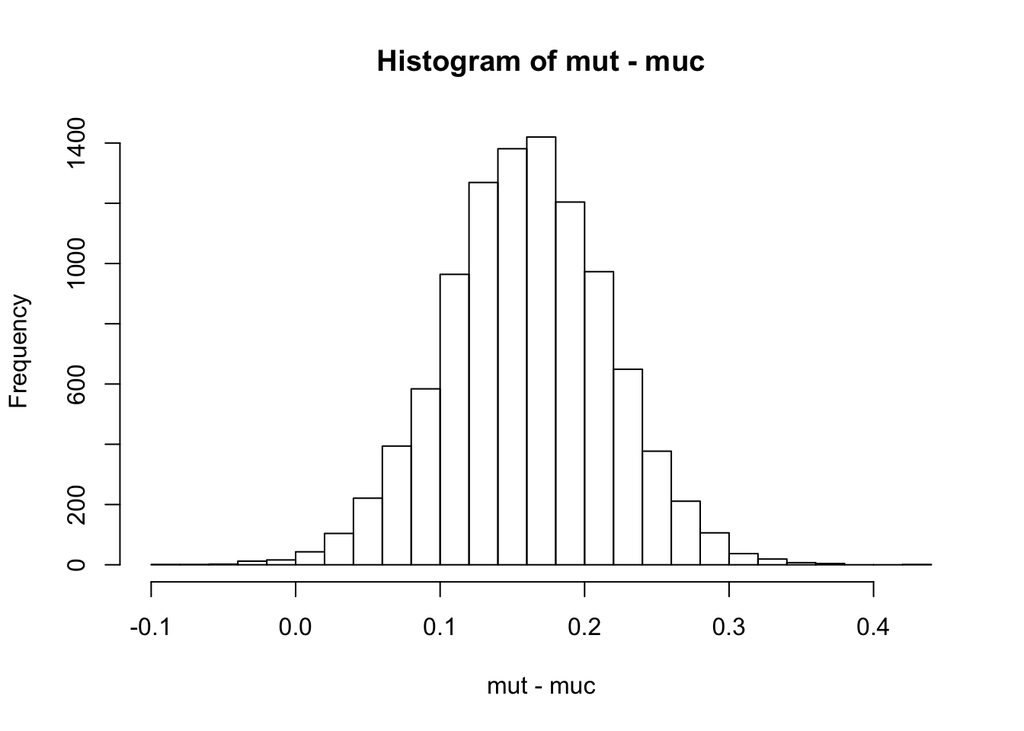

```r
nc <- length(yc)
muc <- mean(yc)+sd(yc)*rt(10000,nc-1)/sqrt(nc)
sigc <- 0
for(k in 1:10000) {
  b=sum((yc-muc[k])^2)/2
  sigc[k]=1/rgamma(1,nc/2,b)
}
hist(mut-muc,25)
```

leads to the following Normal looking plot:

#### (c) Use the simulated means to obtain a 95% posterior credible interval for the difference in means.

```r
quantile(mut-muc,c(0.025,0.975))
```

```
##       2.5%      97.5%
## 0.04842128 0.27119044
```

#### (d) Estimate $Pr(\mu_{T} > \mu_{C} \mid y_{t},y_c)$ using a classical method. (What is meant here, is its equivalent, i.e. a one-sided P-value.)

```r
model_summary <- tidy(t.test(yt,yc))
model_summary
```

```
##   estimate estimate1 estimate2 statistic     p.value parameter   conf.low
## 1 0.160045     1.173  1.012955  2.966284 0.004307655  60.62378 0.05214232
##   conf.high                  method alternative
## 1 0.2679476 Welch Two Sample t-test   two.sided
```

gives p-value = 0.0043077.

This is actually
$$Pr(\mid \bar{y}_{T} - \bar{y}_c \mid / \sqrt{s_T^2/n_{T} + s_c^2 /n_c} > t_{df} \mid \mu_{T} = \mu_{c}).$$
This would seem to suggest to a Bayesian that $Pr(\mu_{T} > \mu_{c} \mid y_{t} , y_c ) \sim 1-0.004308/2 = 0.9978$.